# Prognoza cen surowców

Agnieszka Wrzos

# Pallad (Palladium)

## Odczyt

```
## time series starts 2015-01-02
## time series ends   2021-01-29
```

## acf, pacf, wykres

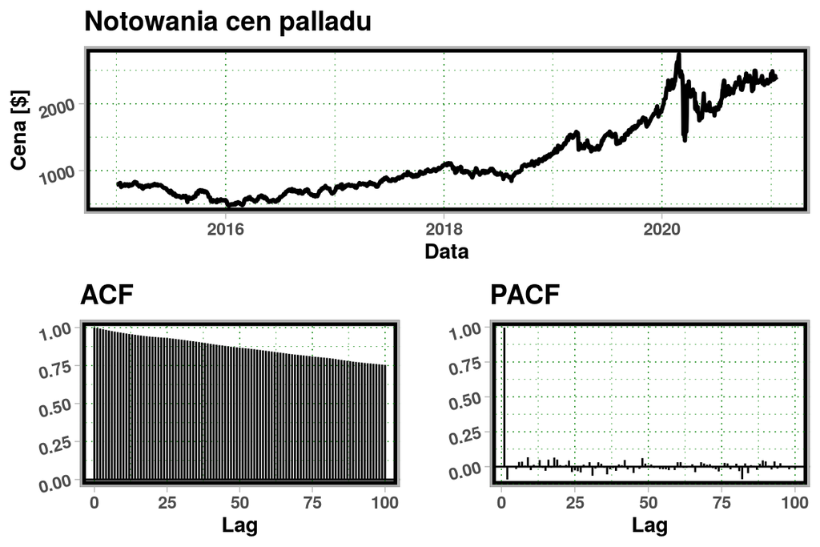

Notowania cen palladu oraz wykresy ACF i PACF

```
## Simple R/S Hurst estimation:         0.8807604
## Corrected R over S Hurst exponent:   1.028014
## Empirical Hurst exponent:            1.050124
## Corrected empirical Hurst exponent:  1.030253
## Theoretical Hurst exponent:          0.5369649
```

Wartość współczynnika Hursta wynosi 0.8807604.

## Testy pierwiastka jednostkowego.

```r
adf.test(palladium) # czyli stopień integracji jest różny od 0
```

```
##
##  Augmented Dickey-Fuller Test
##
## data:  palladium
## Dickey-Fuller = -2.6396, Lag order = 11, p-value = 0.3076
## alternative hypothesis: stationary
```

```r
kpss.test(palladium)
```

```
##
##  KPSS Test for Level Stationarity
##
## data:  palladium
## KPSS Level = 16.117, Truncation lag parameter = 7, p-value = 0.01
```

```r
pp.test(palladium)
```

```
##
##  Phillips-Perron Unit Root Test
##
## data:  palladium
## Dickey-Fuller Z(alpha) = -18.39, Truncation lag parameter = 7, p-value
## = 0.09577
## alternative hypothesis: stationary
```

## Dopasowanie modelu ARFIMA

Do oszacowania parametrów wykorzystano Metodę Najwiekszej Wiarygodności Logarytm z funkcji wiarygodności wynosi -7475.7509858.

Wartości parametrów dla modelu ARFIMA

|  | Estimate | Std. Error | z value | Pr(>\|z\|) |
| --- | --- | --- | --- | --- |
| d | 0.499407 | 0.000836 | 597.556557 | 0.000e+00 |
| ma.ma1 | -0.725706 | 0.025230 | -28.763176 | 6.198e-182 |
| ma.ma2 | -0.501037 | 0.030075 | -16.659703 | 2.573e-62 |
| ma.ma3 | -0.414031 | 0.024749 | -16.729485 | 7.993e-63 |
| ma.ma4 | -0.416607 | 0.028931 | -14.400023 | 5.173e-47 |
| ma.ma5 | -0.222724 | 0.029359 | -7.586149 | 3.296e-14 |

Wykres przedstawia wartości rzeczywiste oraz wartości dopasowane oszacowane na podstawie modelu ARFIMA

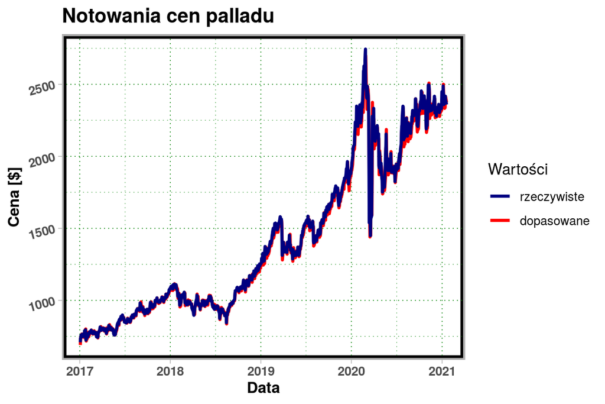

Dopasowanie cen Palladium za pomocą ARFIMA

## Analiza reszt

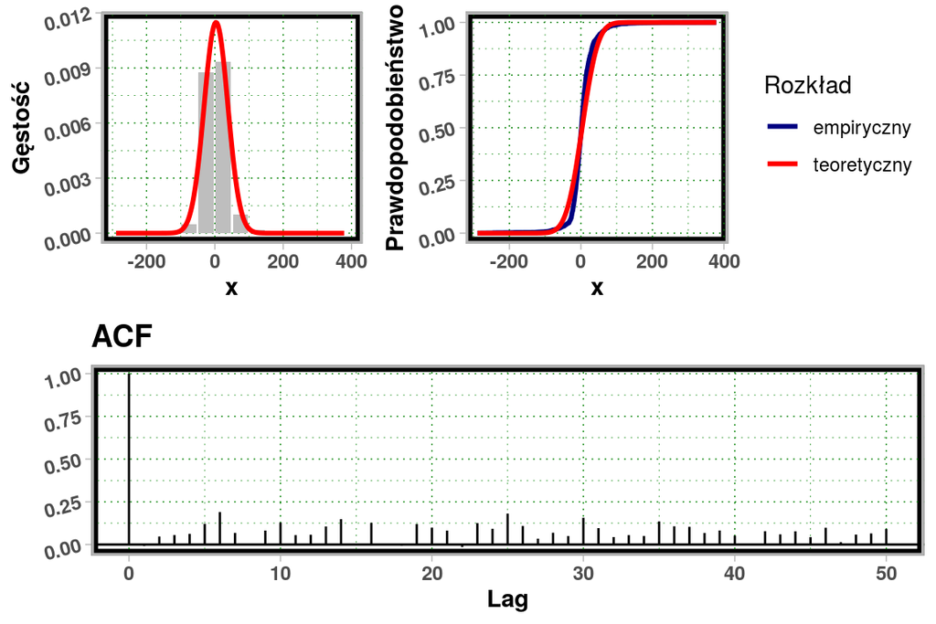

Identyfikacja reszt

## Badanie normalności rozkładu reszt

Wyniki testów badania normalności rozkładu reszt.

| Test | Statystyka | p.val |
| --- | --- | --- |
| Shapiro-Wilka | 0.8168646 | 2.662e-38 |
| Lillieforsa | 0.1223802 | 2.206e-61 |
| Andersona-Darlinga | 52.5395886 | 3.700e-24 |
| Cramera von Misesa | 9.2126024 | 7.370e-10 |

## Analiza niezależności reszt

| $\tau$ | $\rho^{\varepsilon}_{\tau}$ | $\chi^2_{(\tau)}$ | p.val |
| --- | --- | --- | --- |
| 1 | -0.0085346 | 0.1096965 | 0.7404899 |
| 2 | 0.0468446 | 3.4166990 | 0.1811646 |
| 3 | 0.0554492 | 8.0532437 | 0.0449240 |
| 4 | 0.0622202 | 13.8951782 | 0.0076372 |
| 5 | 0.1212801 | 36.1059192 | 0.0000009 |
| 6 | 0.1899685 | 90.6360650 | 0.0000000 |
| 7 | 0.0682357 | 97.6762985 | 0.0000000 |
| 8 | -0.0010871 | 97.6780865 | 0.0000000 |
| 9 | 0.0818426 | 107.8196311 | 0.0000000 |
| 10 | 0.1281892 | 132.7161612 | 0.0000000 |

## Predykcja

| Data | l80 | l95 | u80 | u95 | rzeczywiste | prognozowane |
| --- | --- | --- | --- | --- | --- | --- |
| 2021-01-20 | 2293.607 | 2269.937 | 2383.035 | 2406.705 | 2397.9 | 2338.321 |
| 2021-01-21 | 2244.296 | 2206.863 | 2385.719 | 2423.151 | 2369.8 | 2315.007 |
| 2021-01-22 | 2192.588 | 2145.052 | 2372.184 | 2419.721 | 2359.9 | 2282.386 |
| 2021-01-25 | 2153.241 | 2097.275 | 2364.684 | 2420.650 | 2341.6 | 2258.963 |
| 2021-01-26 | 2127.671 | 2063.687 | 2369.410 | 2433.394 | 2319.7 | 2248.540 |
| 2021-01-27 | 2107.755 | 2037.886 | 2371.726 | 2441.595 | 2305.2 | 2239.740 |

Rysunek poniżej przedstawia wartoći notowania cen Palladium od 2020-05-01 do 2021-01-20 - kolor granatowy. W celu weryfikacji prognoz również na wykresie zaznaczono wartoći rzeczywiste (kolor granatowy) oraz prognozowane (kolor czerwony). Dodatkowo wynaczono przedizały ufności dla poziomu $80 \%$ oraz $95 \%$.

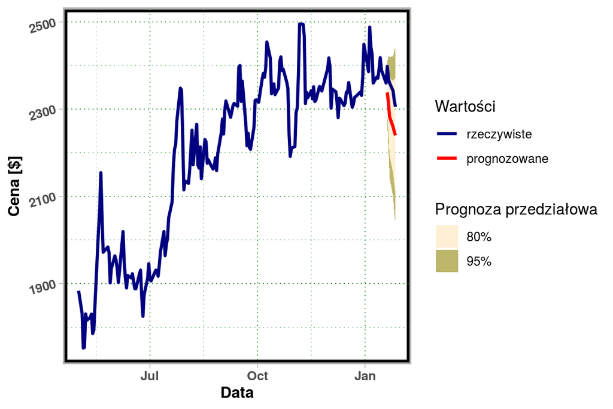

# Kakao (Cocoa)

## Odczyt

```
## time series starts 2015-01-02
## time series ends   2021-01-29
```

## acf, pacf, wykres

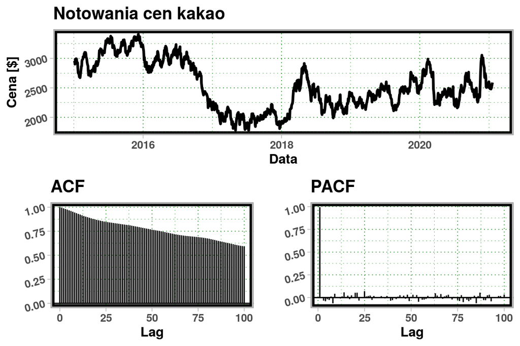

Notowania cen kakao oraz wykresy ACF i PACF

```
## Simple R/S Hurst estimation:         0.8701133
## Corrected R over S Hurst exponent:   0.985099
## Empirical Hurst exponent:            0.9392069
## Corrected empirical Hurst exponent:  0.9207199
## Theoretical Hurst exponent:          0.5369649
```

Wartość współczynnika Hursta wynosi 0.8701133.

## Testy pierwiastka jednostkowego

```r
adf.test(cocoa) # czyli stopień integracji jest różny od 0
```

```
##
##  Augmented Dickey-Fuller Test
##
## data:  cocoa
## Dickey-Fuller = -2.5352, Lag order = 11, p-value = 0.3518
## alternative hypothesis: stationary
```

```r
kpss.test(cocoa)
```

```
##
##  KPSS Test for Level Stationarity
##
## data:  cocoa
## KPSS Level = 6.4071, Truncation lag parameter = 7, p-value = 0.01
```

```r
pp.test(cocoa)
```

```
##
##  Phillips-Perron Unit Root Test
##
## data:  cocoa
## Dickey-Fuller Z(alpha) = -12.32, Truncation lag parameter = 7, p-value
## = 0.4225
## alternative hypothesis: stationary
```

## Dopasowanie modelu ARFIMA

Do oszacowania parametrów wykorzystano Metodę Najwiekszej Wiarygodności Logarytm z funkcji wiarygodności wynosi -7851.9403201, natomiast tabela poniżej podaje wartości parametrów strukturalnych oraz wyniki testu istotności tych parametrów

Wartości parametrów dla modelu ARFIMA

|  | Estimate | Std. Error | z value | Pr(>\|z\|) |
| --- | --- | --- | --- | --- |
| d | 0.019316 | 0.021098 | 0.915548 | 3.599e-01 |
| ar.ar1 | 0.992653 | 0.003321 | 298.869333 | 0.000e+00 |

Wykres przedstawia wartości rzeczywiste oraz wartości dopasowane oszacowane na podstawie modelu ARFIMA

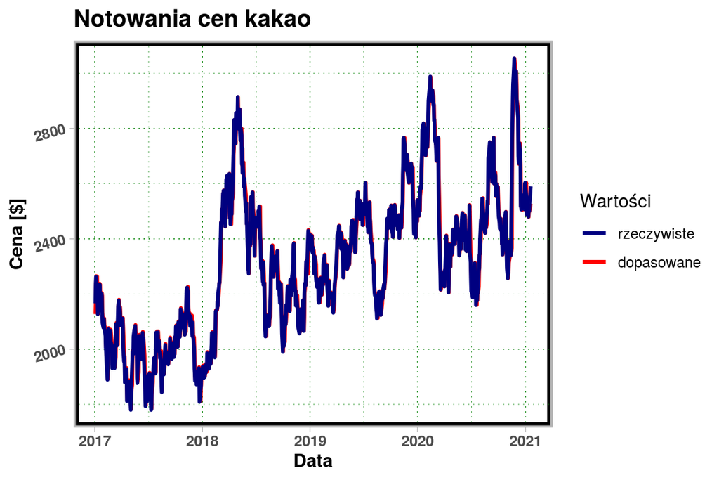

Dopasowanie cen kakao za pomocą ARFIMA

## Analiza reszt

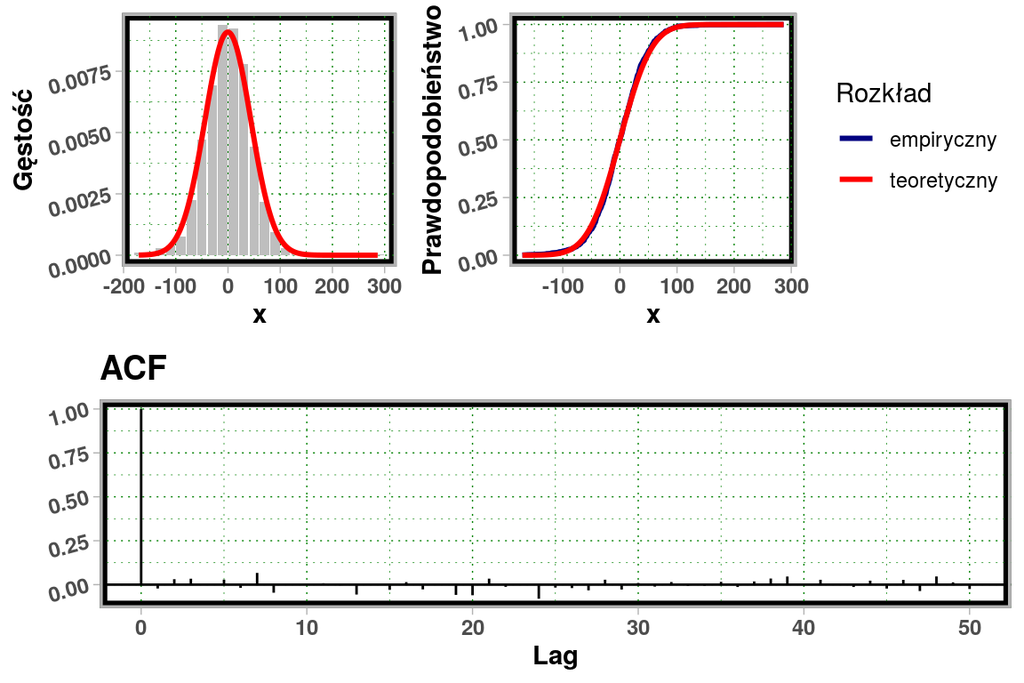

Identyfikacja reszt

Wyniki testów badania normalności rozkładu reszt.

| Test | Statystyka | p.val |
| --- | --- | --- |
| Shapiro-Wilka | 0.9889779 | 2.838e-09 |
| Lillieforsa | 0.0251947 | 2.580e-02 |
| Andersona-Darlinga | 1.4652550 | 8.800e-04 |
| Cramera von Misesa | 0.1988733 | 5.554e-03 |

## Analiza niezależności reszt

| $\tau$ | $\rho^{\varepsilon}_{\tau}$ | $\chi^2_{(\tau)}$ | p.val |
| --- | --- | --- | --- |
| 1 | -0.0218114 | 0.7197902 | 0.3962127 |
| 2 | 0.0312483 | 2.1981529 | 0.3331786 |
| 3 | 0.0339020 | 3.9394278 | 0.2680796 |
| 4 | 0.0053775 | 3.9832678 | 0.4082750 |
| 5 | 0.0282368 | 5.1928179 | 0.3928047 |
| 6 | -0.0183569 | 5.7043601 | 0.4571089 |
| 7 | 0.0669063 | 12.5042874 | 0.0851477 |
| 8 | -0.0457038 | 15.6794336 | 0.0472051 |
| 9 | -0.0029678 | 15.6928313 | 0.0735798 |
| 10 | 0.0007846 | 15.6937684 | 0.1087406 |

## Predykcja

Rysunek poniżej przedstawia wartoći notowania cen kakao od 2020-05-01 do 2021-01-20 - kolor granatowy. W celu weryfikacji prognoz również na wykresie zaznaczono wartoći rzeczywiste (kolor granatowy) oraz prognozowane (kolor czerwony). Dodatkowo wynaczono przedizały ufności dla poziomu $80 \%$ oraz $95 \%$.

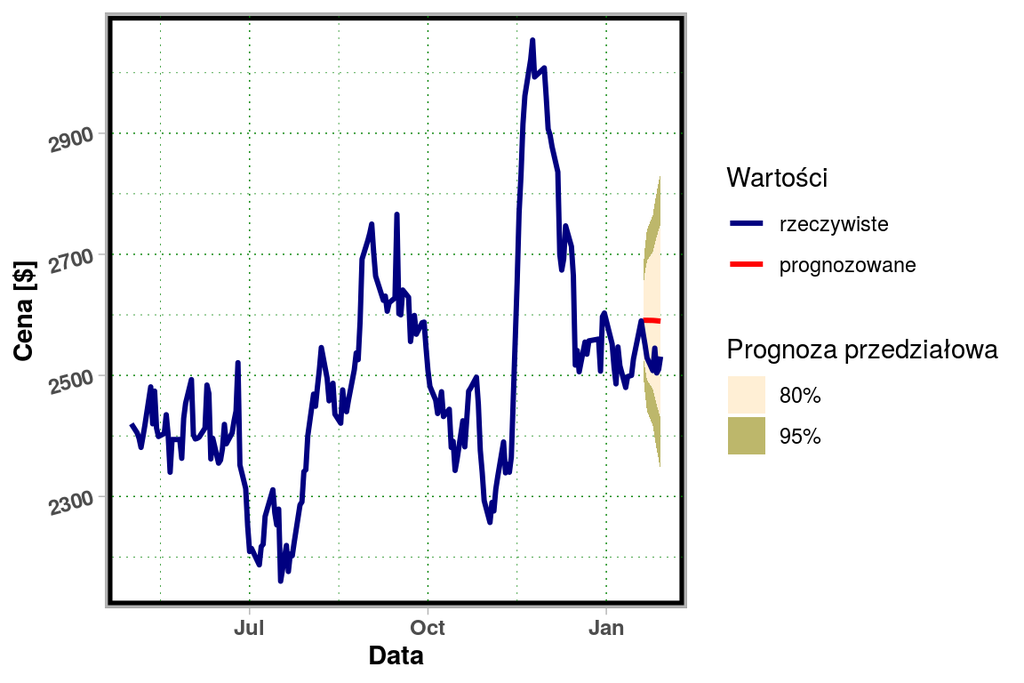

# Olej opałowy (Heating Oil)

## odczyt

```
## time series starts 2015-01-02
## time series ends   2021-01-29
```

## acf, pacf, wykres

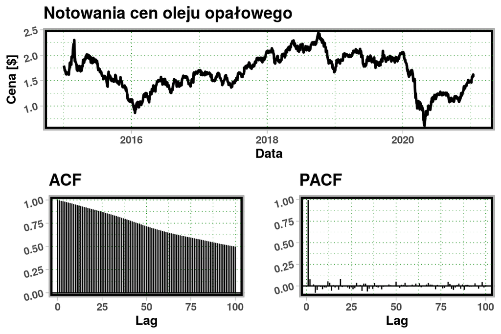

Notowania cen oleju opałowego oraz wykresy ACF i PACF

## Współczynnik Hursta

```
## Simple R/S Hurst estimation:         0.8650253
## Corrected R over S Hurst exponent:   1.001879
## Empirical Hurst exponent:            1.018302
## Corrected empirical Hurst exponent:  0.9993093
## Theoretical Hurst exponent:          0.5369649
```

Wartość współczynnika Hursta wynosi 0.8650253.

## Testy pierwiastka jednostkowego

```r
adf.test(heating_oil)
```

```
##
##  Augmented Dickey-Fuller Test
##
## data:  heating_oil
## Dickey-Fuller = -1.9897, Lag order = 11, p-value = 0.5827
## alternative hypothesis: stationary
```

```r
kpss.test(heating_oil)
```

```
##
##  KPSS Test for Level Stationarity
##
## data:  heating_oil
## KPSS Level = 2.3688, Truncation lag parameter = 7, p-value = 0.01
```

```r
pp.test(heating_oil)
```

```
##
##  Phillips-Perron Unit Root Test
##
## data:  heating_oil
## Dickey-Fuller Z(alpha) = -7.2575, Truncation lag parameter = 7, p-value
## = 0.7049
## alternative hypothesis: stationary
```

## Dopasowanie modelu ARFIMA

Do oszacowania parametrów wykorzystano Metodę Najwiekszej Wiarygodności Logarytm z funkcji wiarygodności wynosi 2820.4364628

Wartości parametrów dla modelu ARFIMA

|  | Estimate | Std. Error | z value | Pr(>\|z\|) |
| --- | --- | --- | --- | --- |
| d | 0.499113 | 0.001248 | 399.900467 | 0.000e+00 |
| ma.ma1 | -0.513813 | 0.019852 | -25.881869 | 1.066e-147 |
| ma.ma2 | -0.429278 | 0.022059 | -19.460567 | 2.371e-84 |
| ma.ma3 | -0.325525 | 0.020885 | -15.586495 | 8.993e-55 |
| ma.ma4 | -0.314377 | 0.022292 | -14.102920 | 3.644e-45 |
| ma.ma5 | -0.195279 | 0.022983 | -8.496574 | 1.953e-17 |

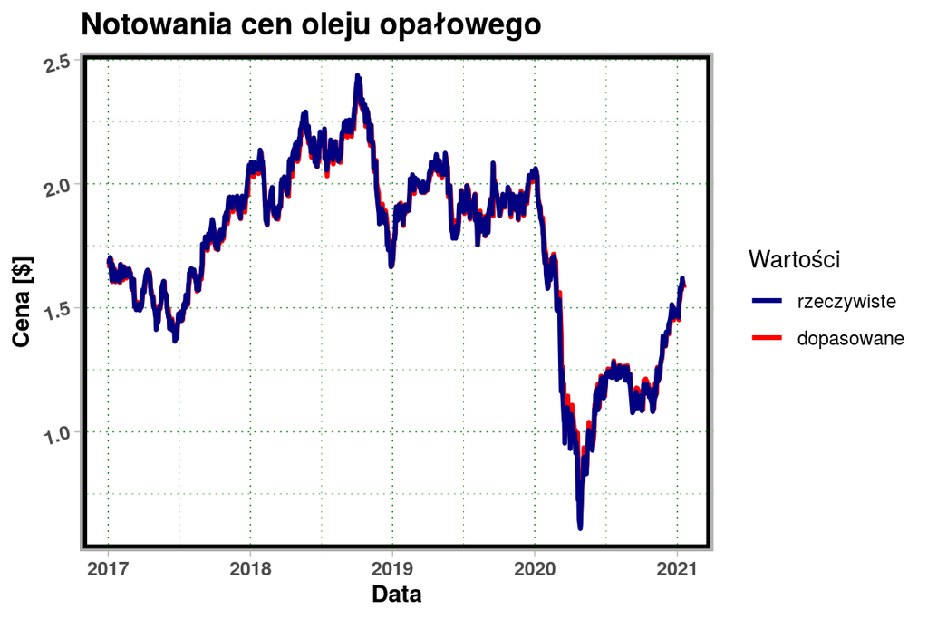

Dopasowanie cen oleju opałowego za pomocą ARFIMA

## Analiza reszt

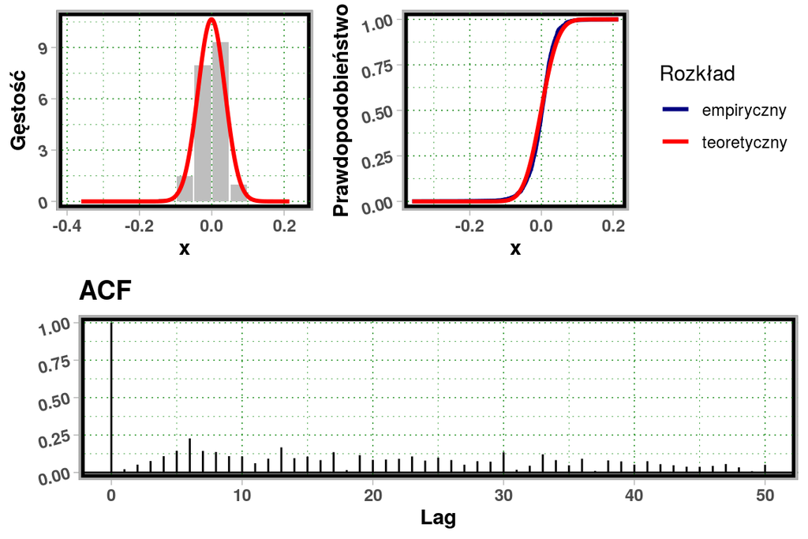

Identyfikacja reszt

## Normalność rozkładu reszt

Wyniki testów badania normalności rozkładu reszt.

| Test | Statystyka | p.val |
| --- | --- | --- |
| Shapiro-Wilka | 0.9423978 | 8.555e-24 |
| Lillieforsa | 0.0549442 | 1.669e-11 |
| Andersona-Darlinga | 9.8611319 | 7.698e-24 |
| Cramera von Misesa | 1.6488603 | 7.370e-10 |

## Analiza niezależności reszt

| $\tau$ | $\rho^{\varepsilon}_{\tau}$ | $\chi^2_{(\tau)}$ | p.val |
| --- | --- | --- | --- |
| 1 | 0.0217923 | 0.7185299 | 0.3966265 |
| 2 | 0.0524480 | 4.8832420 | 0.0870197 |
| 3 | 0.0769704 | 13.8588295 | 0.0031037 |
| 4 | 0.1088777 | 31.8302287 | 0.0000021 |
| 5 | 0.1450987 | 63.7690573 | 0.0000000 |
| 6 | 0.2278527 | 142.5804847 | 0.0000000 |
| 7 | 0.1441998 | 174.1668024 | 0.0000000 |
| 8 | 0.1368460 | 202.6325878 | 0.0000000 |
| 9 | 0.1094094 | 220.8403823 | 0.0000000 |
| 10 | 0.1075169 | 238.4354443 | 0.0000000 |

## Predykcja

| Data | l80 | l95 | u80 | u95 | rzeczywiste | prognozowane |
| --- | --- | --- | --- | --- | --- | --- |
| 2021-01-20 | 1.541514 | 1.516112 | 1.637487 | 1.662890 | 1.6004 | 1.589501 |
| 2021-01-21 | 1.510905 | 1.474747 | 1.647511 | 1.683669 | 1.6006 | 1.579208 |
| 2021-01-22 | 1.480605 | 1.435525 | 1.650921 | 1.696001 | 1.5760 | 1.565763 |
| 2021-01-25 | 1.455779 | 1.403481 | 1.653364 | 1.705662 | 1.5939 | 1.554572 |
| 2021-01-26 | 1.436783 | 1.377841 | 1.659471 | 1.718412 | 1.5984 | 1.548127 |
| 2021-01-27 | 1.418287 | 1.354173 | 1.660516 | 1.724630 | 1.6089 | 1.539401 |
| 2021-01-28 | 1.406718 | 1.339578 | 1.660376 | 1.727516 | 1.6017 | 1.533547 |
| 2021-01-29 | 1.397814 | 1.328428 | 1.659958 | 1.729344 | 1.6004 | 1.528886 |

## Wartości notowania cen oleju opałowego

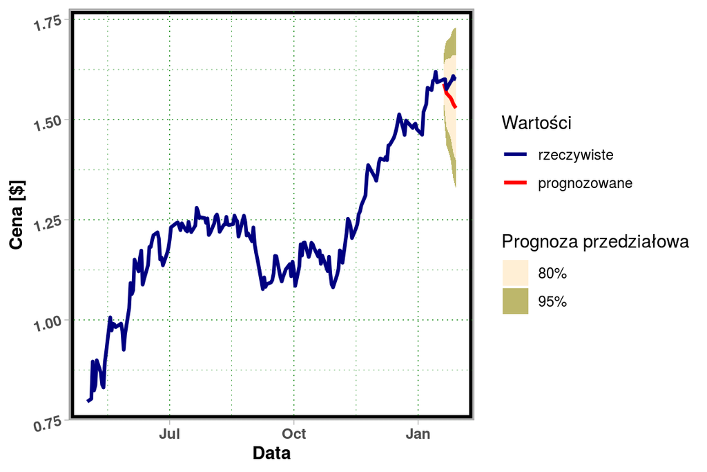